# Unit 12 Homework

### W203 Statistics for Data Science

Student Name: SUHAS GUPTA

Section Number: Section 7

**Data:** The file videos.txt contains data scraped from Youtube.com.

```r
library(car)
library(stargazer)
library(ggplot2)
library(lmtest)
library(sandwich)
```

```r
Data = read.table("videos.txt", sep="\t", header=T)
head(Data)
```

| video_id | uploader | age | category | length | views | rate | ratings | comments |
| --- | --- | --- | --- | --- | --- | --- | --- | --- |
| 9QR1tni70fo | BHJJYP | 1131 | Comedy | 126 | 204 | 3.00 | 2 | 1 |
| l1DCSqAJ740 | musicalrox | 1236 | Music | 243 | 1652 | 3.91 | 11 | 4 |
| ZES_o3XYGjM | tessaceleste | 1243 | Entertainment | 105 | 898 | 4.48 | 81 | 36 |
| 4I8b40cViDE | booloveswondergirls | 1237 | Entertainment | 278 | 928 | 5.00 | 24 | 13 |
| Elp6Bf0HJIM | Fizz101Productionz | 1252 | Comedy | 26 | 392 | 1.50 | 8 | 17 |
| VPuKu7aU9GY | slytherin66 | 1236 | Entertainment | 252 | 318 | 5.00 | 2 | 3 |

**1.0** Conduct a short EDA on the data set espcially focusing on `views`, `rate`, and `length`

```r
str(Data)
```

```
'data.frame':	9489 obs. of  9 variables:
 $ video_id: Factor w/ 9489 levels "-0Zkx9Sh6DU",..: 1466 7237 5357 710 2293 4779 3079 9482 3179 7500 ...
 $ uploader: Factor w/ 7166 levels "","000mdc000",..: 281 5326 6547 2971 844 6271 5869 4301 3250 4665 ...
 $ age     : int  1131 1236 1243 1237 1252 1236 1053 1240 1237 1187 ...
 $ category: Factor w/ 17 levels ""," UNA ","Autos & Vehicles",..: 4 10 6 6 4 6 4 6 10 9 ...
 $ length  : int  126 243 105 278 26 252 162 37 166 139 ...
 $ views   : int  204 1652 898 928 392 318 749 10 115 617 ...
 $ rate    : num  3 3.91 4.48 5 1.5 5 3 0 2 4.67 ...
 $ ratings : int  2 11 81 24 8 2 6 0 1 24 ...
 $ comments: int  1 4 36 13 17 3 6 0 0 17 ...
```

```r
stargazer(Data, type="text")
```

```
============================================================================
Statistic   N     Mean     St. Dev.   Min   Pctl(25) Pctl(75)       Max
----------------------------------------------------------------------------
age       9,480 1,044.201  217.984   0.000  918.750  1,226.000   1,258.000
length    9,480  226.679   237.333   1.000   83.000   298.250    5,289.000
views     9,480 9,374.447 37,350.310 3.000  348.000  6,207.000 1,807,640.000
rate      9,480   3.746     1.788    0.000   3.400     5.000       5.000
ratings   9,480  20.559     73.528   0.000   1.000    15.000     3,801.000
comments  9,480  19.844    155.770   -2.000  1.000    13.000    13,211.000
----------------------------------------------------------------------------
```

```r
na_data = Data[is.na(Data$views)|is.na(Data$rate)|is.na(Data$rate),]
head(na_data)
```

|  | video_id | uploader | age | category | length | views | rate | ratings | comments |
| --- | --- | --- | --- | --- | --- | --- | --- | --- | --- |
| 77 | K3mgk6-Lg08 |  | NA |  | NA | NA | NA | NA | NA |
| 397 | 9ZeJCbJOzFs |  | NA |  | NA | NA | NA | NA | NA |
| 691 | 94RrencQTOY |  | NA |  | NA | NA | NA | NA | NA |
| 1129 | AhDuUydHPM4 |  | NA |  | NA | NA | NA | NA | NA |
| 1138 | fIoVosbHRzk |  | NA |  | NA | NA | NA | NA | NA |
| 1226 | j4TMvvH6GR8 |  | NA |  | NA | NA | NA | NA | NA |

From above, we can see that no data was recorded for 9 rows in the data set and we will thus ignore these rows from our EDA and CLM analysis.

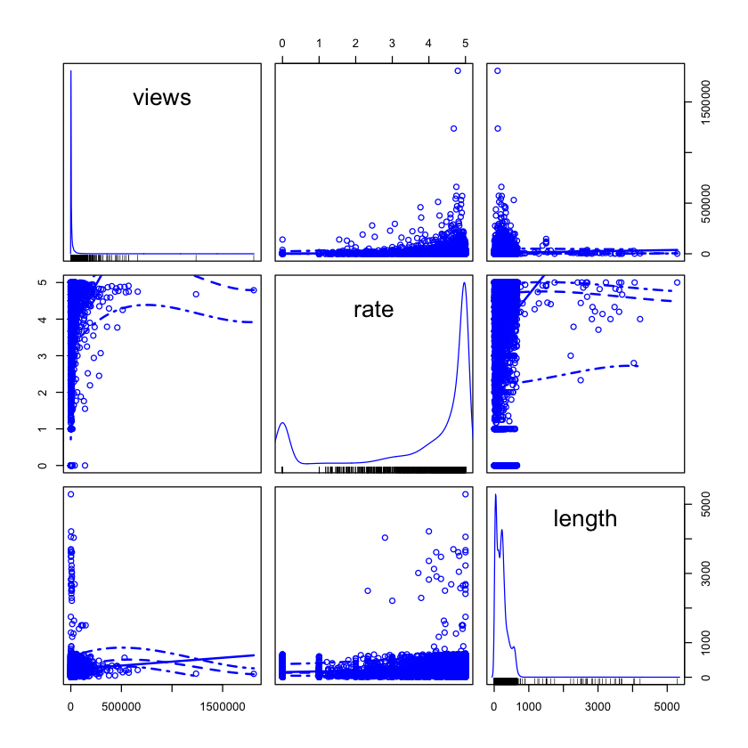

```r
scatterplotMatrix(~ views + rate + length , data = Data)
```

The distributions of `views` and `length` have a large positive skew. I will take the log of these distributions in an attempt to make them normal.

The distribution of `rate` has a peculiar shape with spikes on both ends of values (0 and 5). It seems that the most commonn ratings for videos are 0 and 5 (with 5 being more common) and all other values are less common.

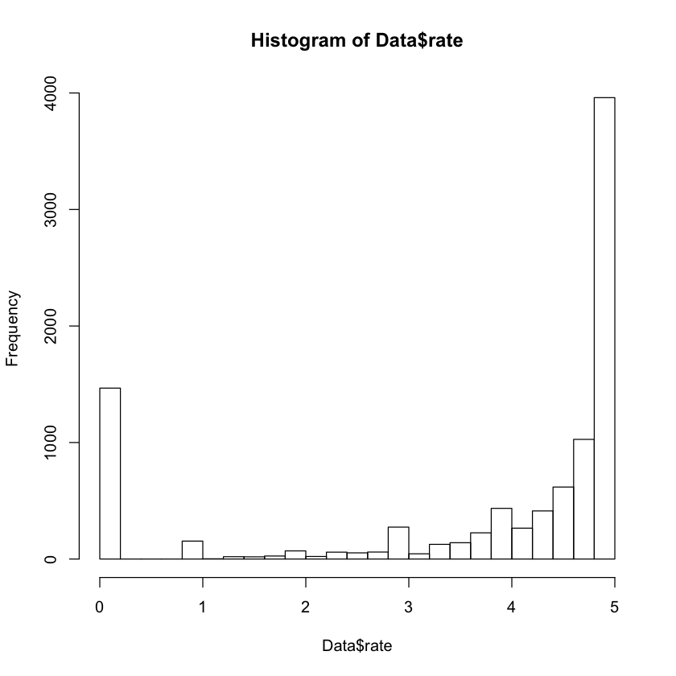

```r
hist(Data$rate, breaks=25)
```

We can transform the variables using a log transformation to normalize the distributions.

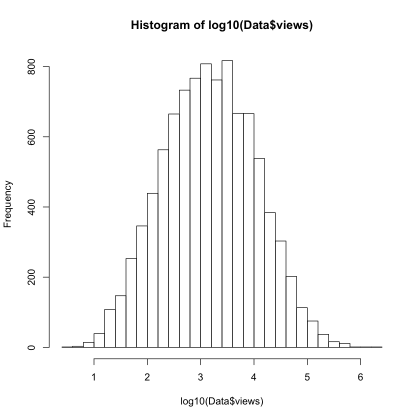

```r
hist(log10(Data$views),breaks=25)
```

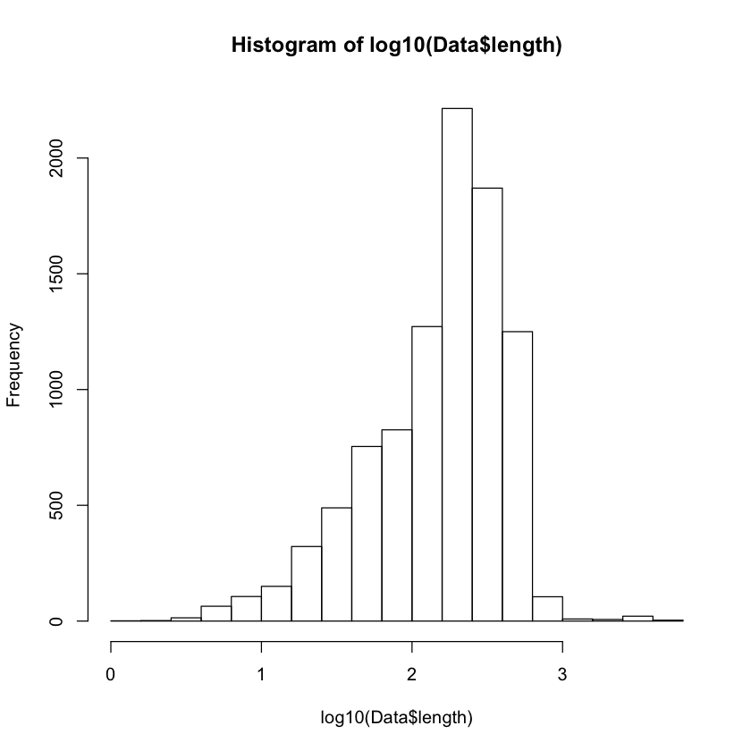

```r
hist(log10(Data$length),breaks=25)
```

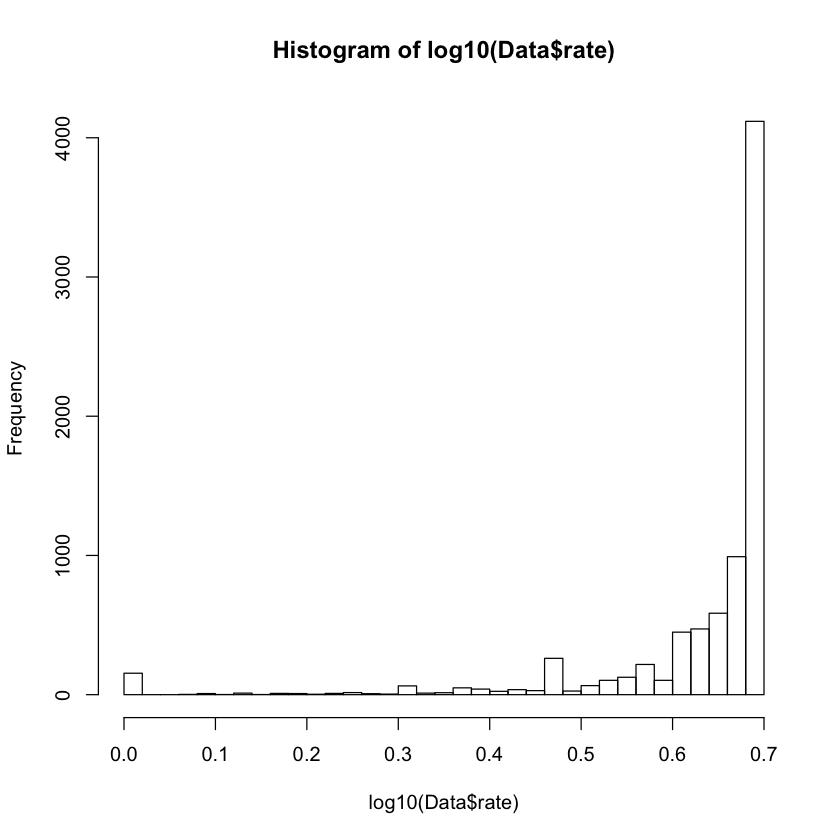

```r
hist(log10(Data$rate),breaks=25)
```

The variables for video views and video length have close to normal distribution after applying the log transformation. However, the variable representing the video ratings is still skewed after applying the log transformation. This is due to the large skew in the data for ratings where a large number of ratings have values 0 and 5. We will use this variable in our model without transformation.

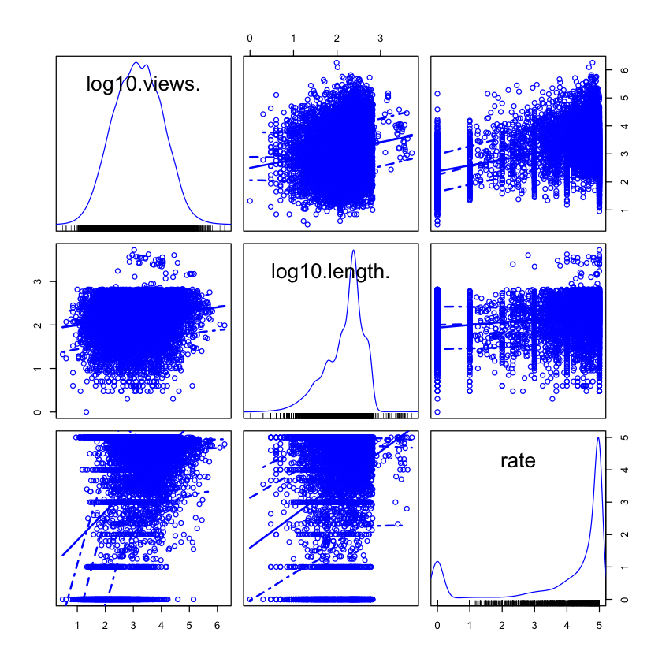

```r
scatterplotMatrix(~ log10(views) + log10(length)  + (rate), data = Data)
```

**2.0** Fit a linear model predicting the number of views (views), from the length of a video (length) and its average user rating (rate).

```r
model = lm(log(views) ~ log10(length) + rate, data= Data)
```

**3.0** Using diagnostic plots, background knowledge, and statistical tests, assess all 6 assumptions of the CLM. When an assumption is violated, state what response you will take.

CLM Assumption 1 : **Linear in parameters**

We assume that the population model for number of views is a linear in parameters with the covariates length of the video and rating of the video. Our model construction above does satify this assumption.

CLM Assumption 2: **Random Sampling**

CLM Assumption 3: **Sample variation and no Perfect collinearity**